# Meauring RMR using Firesting Oxygen Probe and respR (v.2.3.1) control run

Elliott Schmidt

2024-02-28

```r
setwd("C:/Users/jc527762/OneDrive - James Cook University/PhD dissertation/Data/Chapter4_Latitude")
```

```r
library("respR")
library("tidyverse")
library("data.table")
library("hms")
library("kableExtra")
```

### Set working directory

Next we will set the working directory. This should always be done in your Rscripts to make sure your files are being saved to the correct location. It can also make it easier to import files. Not sure what directory you’re in. Try using the **getwd()** function.

```r
setwd("C:/Users/jc527762/OneDrive - James Cook University/PhD dissertation/Data/Chapter4_Latitude")
```

### Importing data from Firesting

Now we will import our firesting file. There are a couple special notes to make about code that was run above. The code above was imported via the package *readr* which gets loaded when load the *tidyverse* package. This has the benefit of letting you see what the dataframe will look like before importing it and I highly suggest you do this the first time that you import your data. Secondly, you may have to **skip** the first 19 rows from the firesting file as these rows contain metadata, and not the actually oxygen data that you will be using.  
#### Importing experiment data

```r
firesting <- read_delim("C:/Users/jc527762/OneDrive - James Cook University/PhD dissertation/Data/2023/2023_CTmaxResp/Experiment_ 29 May 2023 09 53AM/Oxygen data raw/firesting.txt",
                             delim = "\t", escape_double = FALSE,
                             col_types = cols(`...2` = col_time(format = "%H:%M:%S")),
                             trim_ws = TRUE, skip = 18)
firesting <- firesting[-1,]
```

#### Important Note 1

If you have multiple columns with oxygen data and wanted to expect them all at once you could use the code below:

```r
firesting2 <- firesting %>%
  select(c(1:3,5:8,10)) %>%
  rename(TIME = ...2,
         dTIME = ...3,
         DATE = ...1,
         ch1 = Oxygen...5,
         ch2 = Oxygen...6,
         ch3 = Oxygen...7,
         ch4 = Oxygen...8) %>%
  select(c("dTIME", "ch1","ch2","ch3","ch4","TIME","Temperature")) %>%
  #rename(Oxygen = chamber) %>%
  mutate(dTIME = as.numeric(dTIME),
         #Oxygen = as.numeric(Oxygen),
         TIME = as.character(TIME),
         Temp = as.numeric(Temperature))



firesting3 <- firesting %>%
  select(c(3,5:8,10)) %>%
  rename(dTIME = ...3,
         ch1 = Oxygen...5,
         ch2 = Oxygen...6,
         ch3 = Oxygen...7,
         ch4 = Oxygen...8) %>%
  mutate(dTIME = as.numeric(dTIME),
         ch1 = as.numeric(ch1),
         ch2 = as.numeric(ch2),
         ch3 = as.numeric(ch3),
         ch4 = as.numeric(ch4),
         Temperature = as.numeric(Temperature))

inspect(firesting3, time = 1, oxygen = 2:5, add.data = "Temperature" )
```

```
## inspect: Multiple 'oxygen' columns selected. Note that subsequent functions in respR will by default use first oxygen column only.
```

```
## inspect: Data issues detected. For more information use print().
```

```
##
## # print.inspect # -----------------------
##                 dTIME  ch1  ch2  ch3  ch4
## numeric          pass pass pass pass pass
## Inf/-Inf         pass pass pass pass pass
## NA/NaN           pass pass pass pass pass
## sequential       pass    -    -    -    -
## duplicated       pass    -    -    -    -
## evenly-spaced    WARN    -    -    -    -
##
## Uneven Time data locations (first 20 shown) in column: dTIME
##  [1]  1  2  3  4  5  6  7  8 11 18 19 20 21 22 23 25 26 28 30 31
## Minimum and Maximum intervals in uneven Time data:
## [1] 0.94 1.28
## -----------------------------------------
```

```
## plot.inspect: Additional data source cannot be plotted for multiple columns.
```

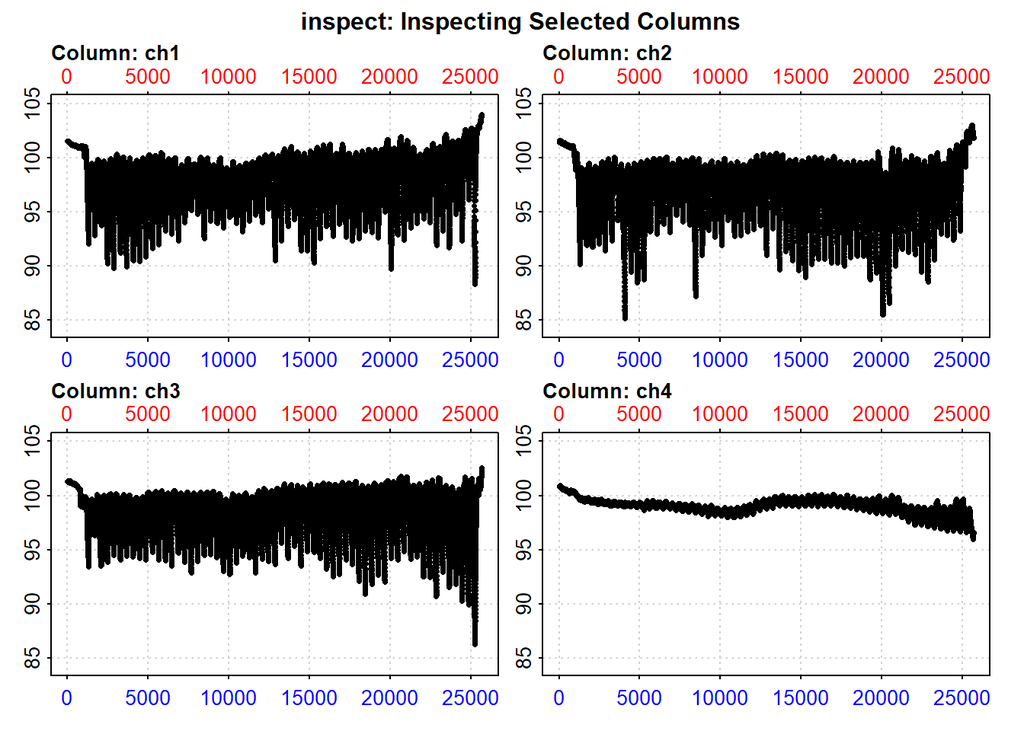

### Calculate background and speciemen rates

Before we move forward and calculate rates of oxygen use, we need to calculate background rates so that they can be extracted from the data. In this example we will be extracting both **pre-** and **post** experiment background rates.

```r
#--- background rates ---#
bg_start <- inspect(firesting3, time = 1, oxygen =5) |>
  subset_data(from = 2272,
              to = 2451,
              by="row") |>
  calc_rate.bg()
```

```
## inspect: Data issues detected. For more information use print().
```

```
##
## # print.inspect # -----------------------
##                 dTIME  ch4
## numeric          pass pass
## Inf/-Inf         pass pass
## NA/NaN           pass pass
## sequential       pass    -
## duplicated       pass    -
## evenly-spaced    WARN    -
##
## Uneven Time data locations (first 20 shown) in column: dTIME
##  [1]  1  2  3  4  5  6  7  8 11 18 19 20 21 22 23 25 26 28 30 31
## Minimum and Maximum intervals in uneven Time data:
## [1] 0.94 1.28
## -----------------------------------------
```

```
## calc_rate.bg: Applying column default of 'time = 1'
```

```
## calc_rate.bg: Applying column default of all non-time column(s) as 'oxygen'
```

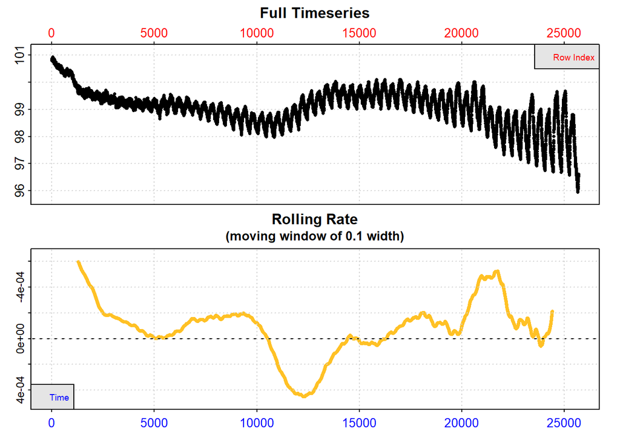

```
##
## # plot.calc_rate.bg # -------------------
```

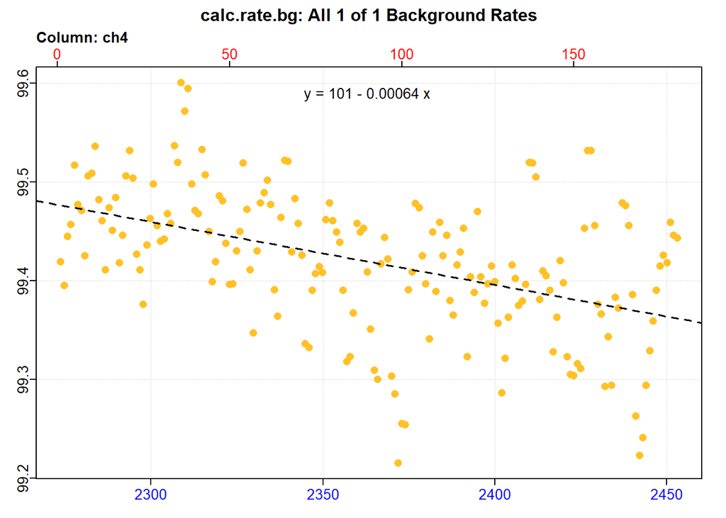

```
## plot.calc_rate.bg: Plotting all 1 background rates ...
## -----------------------------------------
```

```r
bg_end <- inspect(firesting3, time = 1, oxygen =5) |>
  subset_data(from = 25604,
              to = 25654,
              by="row") |>
  calc_rate.bg()
```

```
## inspect: Data issues detected. For more information use print().
```

```
##
## # print.inspect # -----------------------
##                 dTIME  ch4
## numeric          pass pass
## Inf/-Inf         pass pass
## NA/NaN           pass pass
## sequential       pass    -
## duplicated       pass    -
## evenly-spaced    WARN    -
##
## Uneven Time data locations (first 20 shown) in column: dTIME
##  [1]  1  2  3  4  5  6  7  8 11 18 19 20 21 22 23 25 26 28 30 31
## Minimum and Maximum intervals in uneven Time data:
## [1] 0.94 1.28
## -----------------------------------------
```

```
## calc_rate.bg: Applying column default of 'time = 1'
## calc_rate.bg: Applying column default of all non-time column(s) as 'oxygen'
```

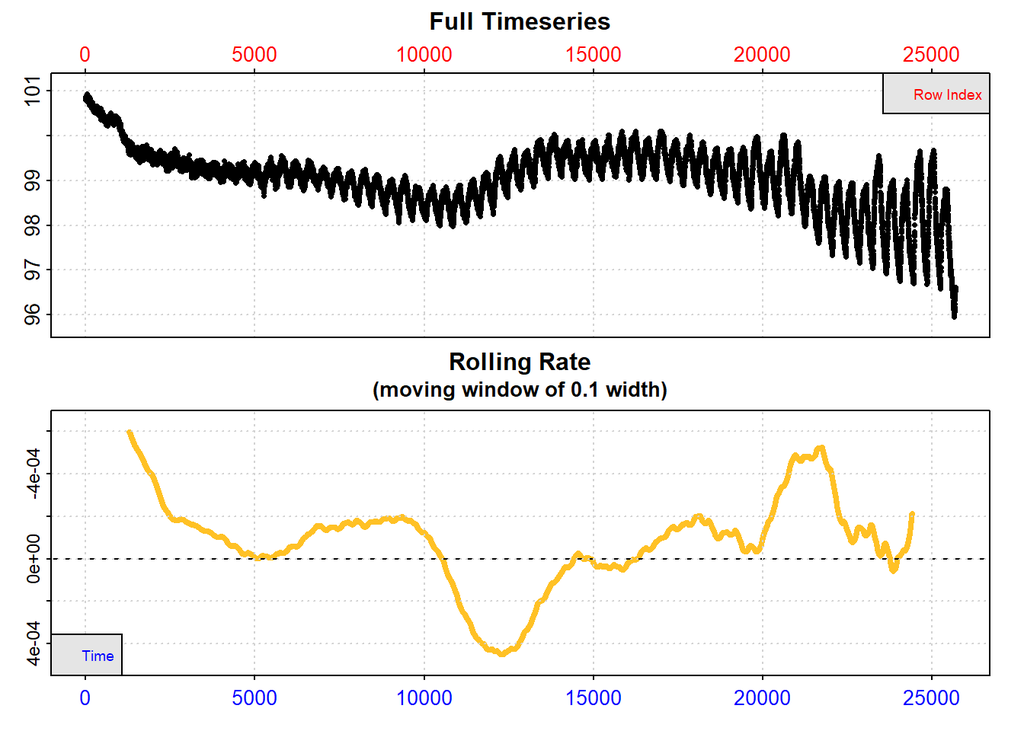

```
##
## # plot.calc_rate.bg # -------------------
```

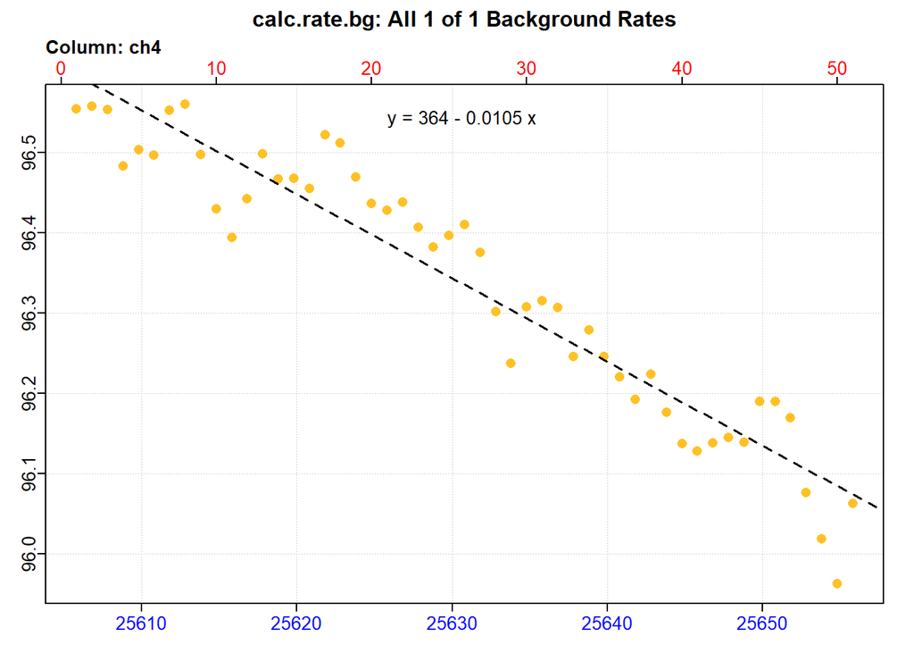

```
## plot.calc_rate.bg: Plotting all 1 background rates ...
## -----------------------------------------
```

```r
#--- speciement rates ---#
apoly1 <- inspect(firesting3, time = 1, oxygen =2) |>
  subset_data(from = 2272,
              to = 25654,
              by="row") |>
  calc_rate.int(starts = 400,
                wait = 20,
                measure= 160,
                by = "row")
```

```
## inspect: Data issues detected. For more information use print().
```

```
##
## # print.inspect # -----------------------
##                 dTIME  ch1
## numeric          pass pass
## Inf/-Inf         pass pass
## NA/NaN           pass pass
## sequential       pass    -
## duplicated       pass    -
## evenly-spaced    WARN    -
##
## Uneven Time data locations (first 20 shown) in column: dTIME
##  [1]  1  2  3  4  5  6  7  8 11 18 19 20 21 22 23 25 26 28 30 31
## Minimum and Maximum intervals in uneven Time data:
## [1] 0.94 1.28
## -----------------------------------------
```

```
##
## # plot.calc_rate.int # ------------------
## plot.calc_rate.int: Plotting rate from all replicates ...
```

```
## plot.calc_rate.int: Plotting first 20 selected reps only. To plot others modify 'pos' input.
```

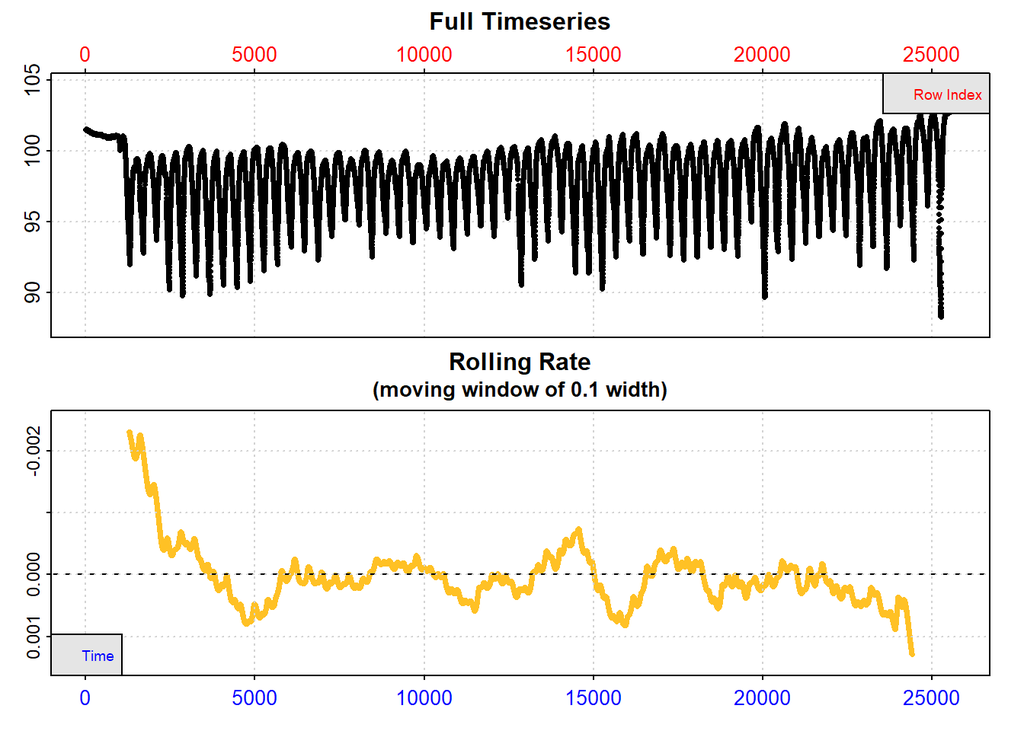

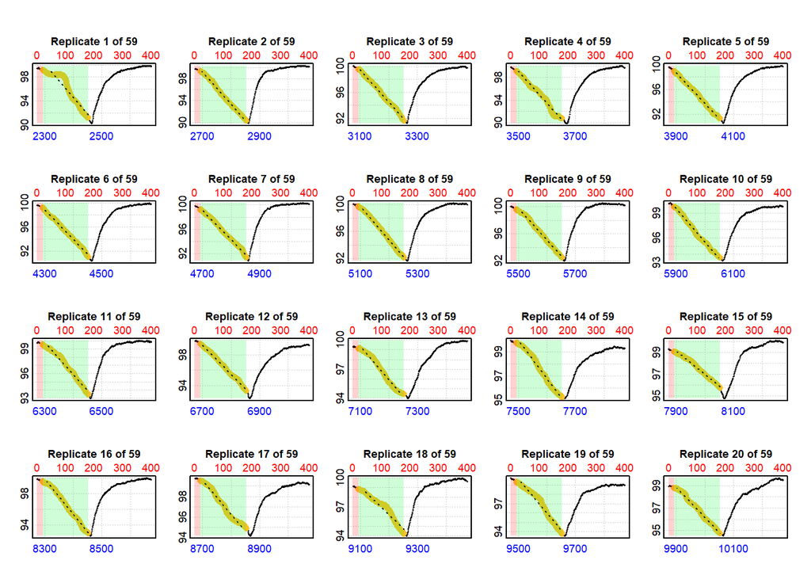

```r
#--- speciement rates ---#
apoly2 <- inspect(firesting3, time = 1, oxygen =3) |>
  subset_data(from = 2272,
              to = 25654,
              by="row") |>
  calc_rate.int(starts = 400,
                wait = 20,
                measure= 160,
                by = "row")
```

```
## inspect: Data issues detected. For more information use print().
```

```
##
## # print.inspect # -----------------------
##                 dTIME  ch2
## numeric          pass pass
## Inf/-Inf         pass pass
## NA/NaN           pass pass
## sequential       pass    -
## duplicated       pass    -
## evenly-spaced    WARN    -
##
## Uneven Time data locations (first 20 shown) in column: dTIME
##  [1]  1  2  3  4  5  6  7  8 11 18 19 20 21 22 23 25 26 28 30 31
## Minimum and Maximum intervals in uneven Time data:
## [1] 0.94 1.28
## -----------------------------------------
```

```
##
## # plot.calc_rate.int # ------------------
## plot.calc_rate.int: Plotting rate from all replicates ...
```

```
## plot.calc_rate.int: Plotting first 20 selected reps only. To plot others modify 'pos' input.
```

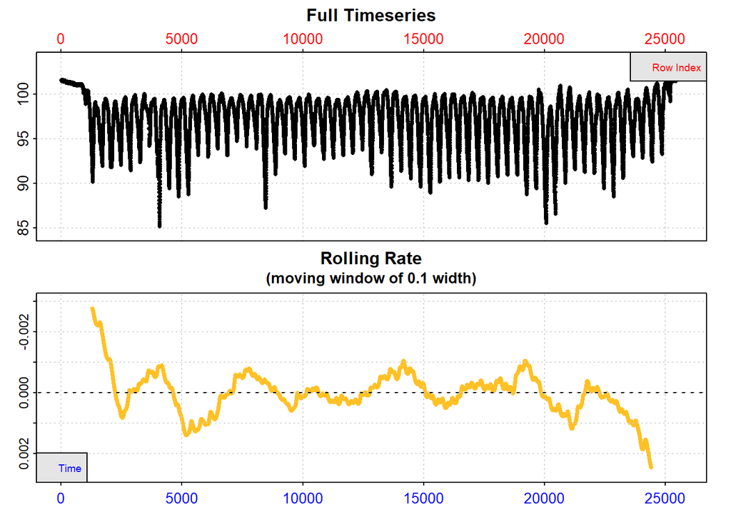

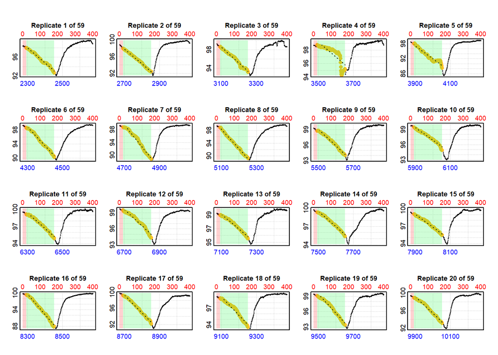

```r
#--- speciement rates ---#
apoly3 <- inspect(firesting3, time = 1, oxygen =4) |>
  subset_data(from = 2272,
              to = 25654,
              by="row") |>
  calc_rate.int(starts = 400,
                wait = 20,
                measure= 160,
                by = "row")
```

```
## inspect: Data issues detected. For more information use print().
```

```
##
## # print.inspect # -----------------------
##                 dTIME  ch3
## numeric          pass pass
## Inf/-Inf         pass pass
## NA/NaN           pass pass
## sequential       pass    -
## duplicated       pass    -
## evenly-spaced    WARN    -
##
## Uneven Time data locations (first 20 shown) in column: dTIME
##  [1]  1  2  3  4  5  6  7  8 11 18 19 20 21 22 23 25 26 28 30 31
## Minimum and Maximum intervals in uneven Time data:
## [1] 0.94 1.28
## -----------------------------------------
```

```
##
## # plot.calc_rate.int # ------------------
## plot.calc_rate.int: Plotting rate from all replicates ...
```

```
## plot.calc_rate.int: Plotting first 20 selected reps only. To plot others modify 'pos' input.
```

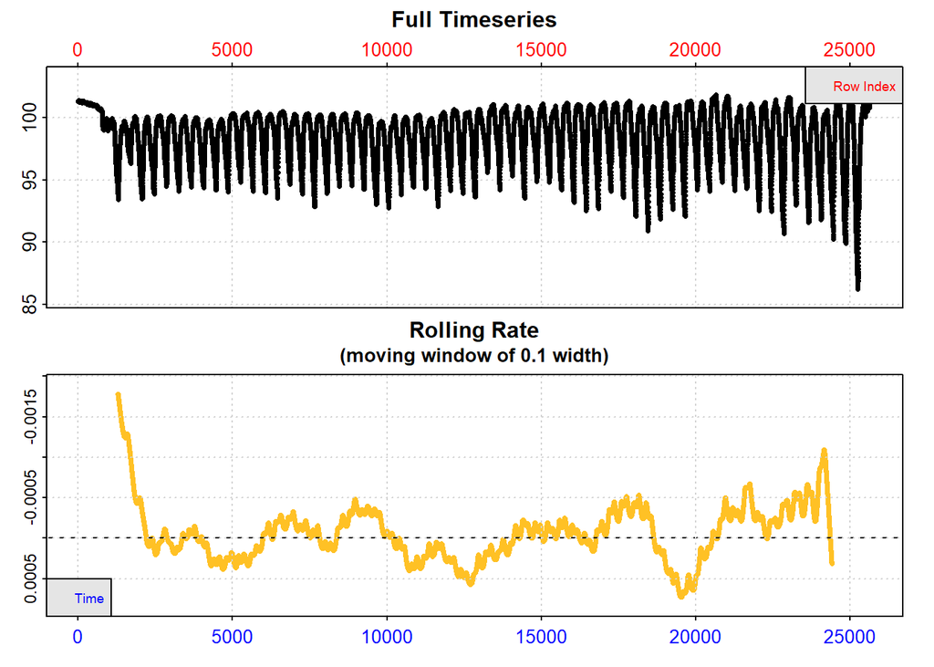

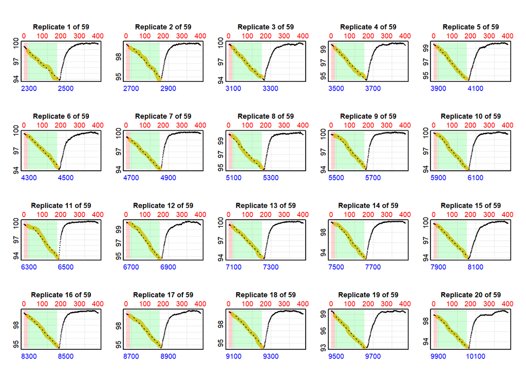

### Adjust rates

```r
apoly1_adj <- adjust_rate(apoly1,
                          by = bg_start,
                          by2 = bg_end,
                          method = "linear")
```

```
## adjust_rate: Rate adjustments applied using "linear" method.
```

```r
apoly2_adj <- adjust_rate(apoly2,
                          by = bg_start,
                          by2 = bg_end,
                          method = "linear")
```

```
## adjust_rate: Rate adjustments applied using "linear" method.
```

```r
apoly3_adj <- adjust_rate(apoly3,
                          by = bg_start,
                          by2 = bg_end,
                          method = "linear")
```

```
## adjust_rate: Rate adjustments applied using "linear" method.
```

### Convert the adjust rates to useable units

```r
apoly_cr.int_conv_1 <- convert_rate(apoly1_adj,
                                oxy.unit = "%Air",
                                time.unit = "secs",
                                output.unit = "mg/h/kg",
                                volume = 0.07160,
                                mass = 0.0013895,
                                S = 37,
                                t = 30, # will implement shared code in future
                                P = 1.019)
```

```
## convert_rate: Object of class 'adjust_rate' detected. Converting all adjusted rates in '$rate.adjusted'.
```

```r
apoly_cr.int_conv_2 <- convert_rate(apoly2_adj,
                                oxy.unit = "%Air",
                                time.unit = "secs",
                                output.unit = "mg/h/kg",
                                volume = 0.07160,
                                mass = 0.0018331,
                                S = 37,
                                t = 30, # will implement shared code in future
                                P = 1.019)
```

```
## convert_rate: Object of class 'adjust_rate' detected. Converting all adjusted rates in '$rate.adjusted'.
```

```r
apoly_cr.int_conv_3 <- convert_rate(apoly3_adj,
                                oxy.unit = "%Air",
                                time.unit = "secs",
                                output.unit = "mg/h/kg",
                                volume = 0.07160,
                                mass = 0.0018397,
                                S = 37,
                                t = 30, # will implement shared code in future
                                P = 1.019)
```

```
## convert_rate: Object of class 'adjust_rate' detected. Converting all adjusted rates in '$rate.adjusted'.
```

```r
summary(apoly_cr.int_conv_1); summary(apoly_cr.int_conv_2); summary(apoly_cr.int_conv_3)
```

```
##
## # summary.convert_rate # ----------------
## Summary of all converted rates:
##
##     rep rank intercept_b0     slope_b1   rsq density   row endrow     time
##  1:   1    1    227.57556 -0.055404374 0.902      NA    21    180  2293.84
##  2:   2    1    258.21004 -0.058869453 0.997      NA   421    580  2694.62
##  3:   3    1    253.98360 -0.049826756 0.997      NA   821    980  3095.11
##  4:   4    1    293.48466 -0.055576246 0.983      NA  1221   1380  3493.85
##  5:   5    1    290.53563 -0.049185486 0.997      NA  1621   1780  3893.80
## ---
## 55:  55    1    864.79255 -0.031946068 0.930      NA 21621  21780 23893.80
## 56:  56    1   1294.27810 -0.049103714 0.992      NA 22021  22180 24293.80
## 57:  57    1    734.07945 -0.025583625 0.963      NA 22421  22580 24693.80
## 58:  58    1   2286.34700 -0.086935584 0.858      NA 22821  22980 25093.80
```

[output cut: 38 more lines]

```
##
## # summary.convert_rate # ----------------
## Summary of all converted rates:
##
##     rep rank intercept_b0     slope_b1   rsq density   row endrow     time
##  1:   1    1    172.47102 -0.032382184 0.987      NA    21    180  2293.84
##  2:   2    1    193.91346 -0.035567494 0.994      NA   421    580  2694.62
##  3:   3    1    205.96993 -0.034639603 0.978      NA   821    980  3095.11
##  4:   4    1    177.53074 -0.022377691 0.669      NA  1221   1380  3493.85
##  5:   5    1    298.96778 -0.051750406 0.935      NA  1621   1780  3893.80
## ---
## 55:  55    1    969.34311 -0.036409707 0.995      NA 21621  21780 23893.80
## 56:  56    1   1209.46142 -0.045660112 0.947      NA 22021  22180 24293.80
## 57:  57    1   1161.80296 -0.042960843 0.993      NA 22421  22580 24693.80
## 58:  58    1    -48.78316  0.005932847 0.138      NA 22821  22980 25093.80
```

[output cut: 38 more lines]

```
##
## # summary.convert_rate # ----------------
## Summary of all converted rates:
##
##     rep rank intercept_b0      slope_b1      rsq density   row endrow     time
##  1:   1    1     165.1119 -2.891997e-02 0.973000      NA    21    180  2293.84
##  2:   2    1     181.5209 -3.031691e-02 0.973000      NA   421    580  2694.62
##  3:   3    1     197.0510 -3.161024e-02 0.993000      NA   821    980  3095.11
##  4:   4    1     201.0659 -2.915170e-02 0.990000      NA  1221   1380  3493.85
##  5:   5    1     222.9615 -3.175162e-02 0.995000      NA  1621   1780  3893.80
## ---
## 55:  55    1    1074.2780 -4.081062e-02 0.983000      NA 21621  21780 23893.80
## 56:  56    1    1411.1288 -5.398809e-02 0.992000      NA 22021  22180 24293.80
## 57:  57    1    1819.1715 -6.959941e-02 0.994000      NA 22421  22580 24693.80
## 58:  58    1    2439.0552 -9.317765e-02 0.992000      NA 22821  22980 25093.80
```

[output cut: 38 more lines]

### Pre-Quailty control

```
##
## # plot.convert_rate # -------------------
```

```
## plot.convert_rate: Plotting all rate(s)...
```

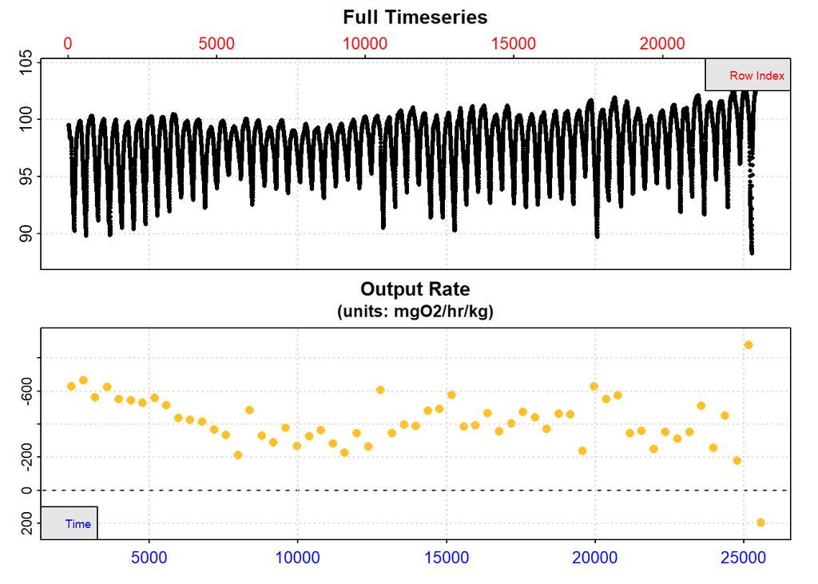

```
##
## # plot.convert_rate # -------------------
```

```
## plot.convert_rate: Plotting all rate(s)...
```

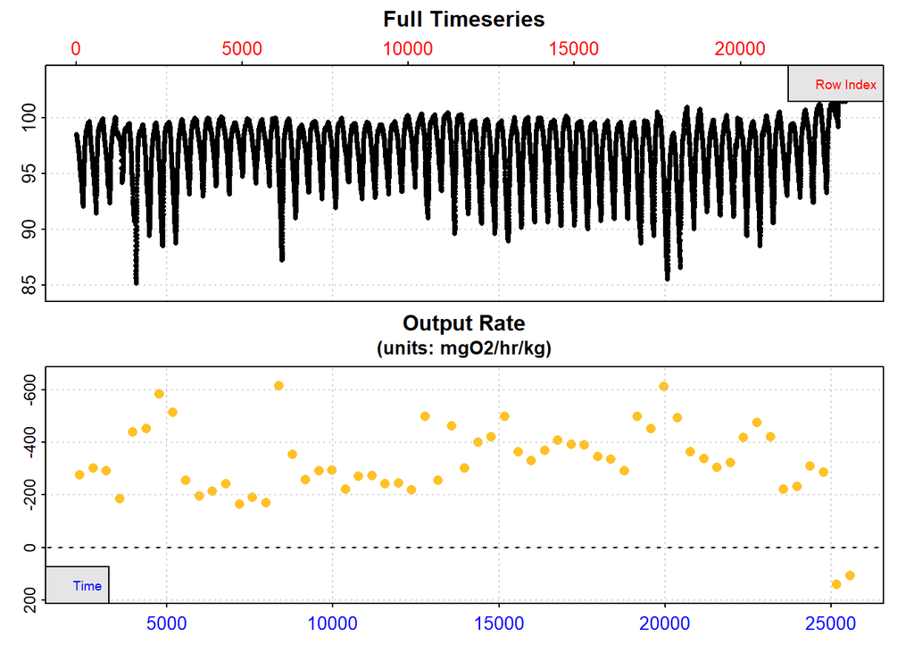

```
##
## # plot.convert_rate # -------------------
```

```
## plot.convert_rate: Plotting all rate(s)...
```

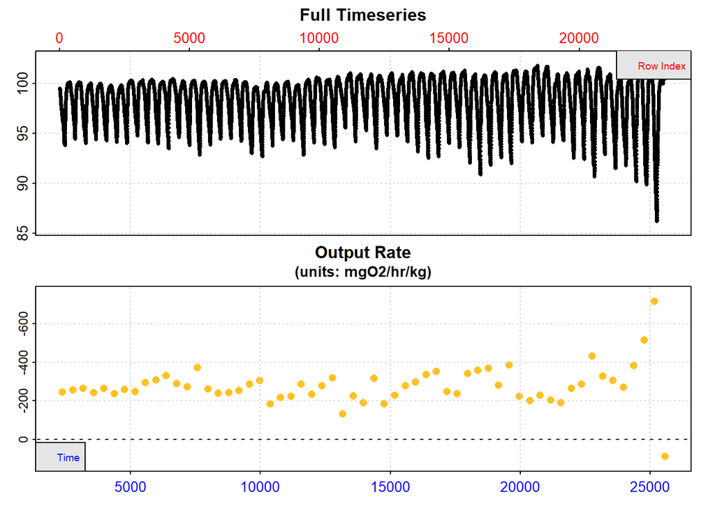

```r
plot(apoly_cr.int_conv_1, type = "rate"); plot(apoly_cr.int_conv_2, type = "rate"); plot(apoly_cr.int_conv_3, type = "rate")
```

### Post-Quailty control

```r
RMR1 <- apoly_cr.int_conv_1 |>
  select_rate(method = "rsq", n = c(0.95, 1))
```

```
## select_rate: Object contains both negative and positive rates. Ensure the chosen `method` is appropriate.
```

```
## select_rate: Selecting rates with rsq values between 0.95 and 1...
```

```
## ----- Selection complete. 9 rate(s) removed, 50 rate(s) remaining -----
```

```r
RMR2 <- apoly_cr.int_conv_2 |>
  select_rate(method = "rsq", n = c(0.95, 1))
```

```
## select_rate: Object contains both negative and positive rates. Ensure the chosen `method` is appropriate.
```

```
## select_rate: Selecting rates with rsq values between 0.95 and 1...
```

```
## ----- Selection complete. 6 rate(s) removed, 53 rate(s) remaining -----
```

```r
RMR3 <- apoly_cr.int_conv_3 |>
  select_rate(method = "rsq", n = c(0.95, 1))
```

```
## select_rate: Object contains both negative and positive rates. Ensure the chosen `method` is appropriate.
```

```
## select_rate: Selecting rates with rsq values between 0.95 and 1...
```

```
## ----- Selection complete. 3 rate(s) removed, 56 rate(s) remaining -----
```

```
##
## # plot.convert_rate # -------------------
```

```
## plot.convert_rate: Plotting all rate(s)...
```

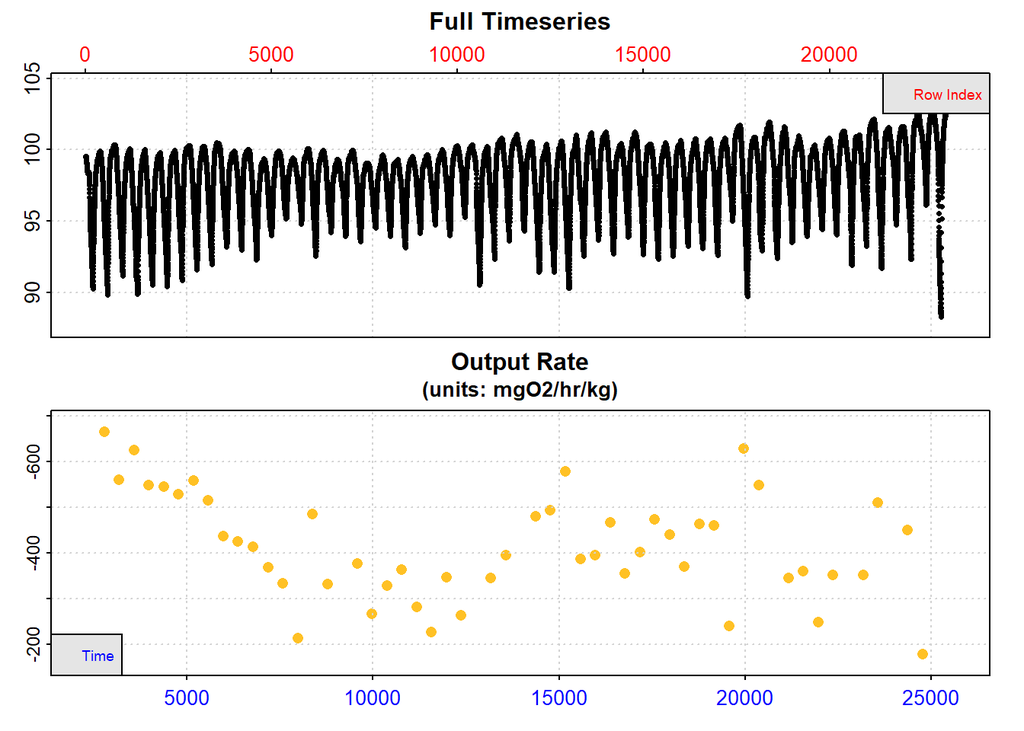

```
##
## # plot.convert_rate # -------------------
```

```
## plot.convert_rate: Plotting all rate(s)...
```

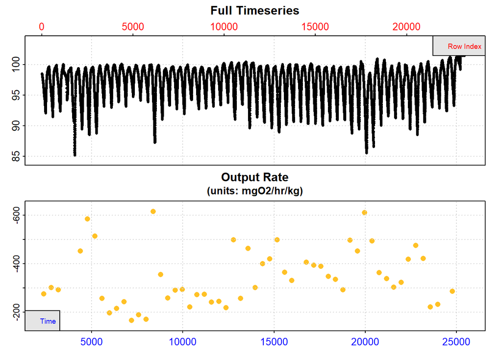

```
##
## # plot.convert_rate # -------------------
```

```
## plot.convert_rate: Plotting all rate(s)...
```

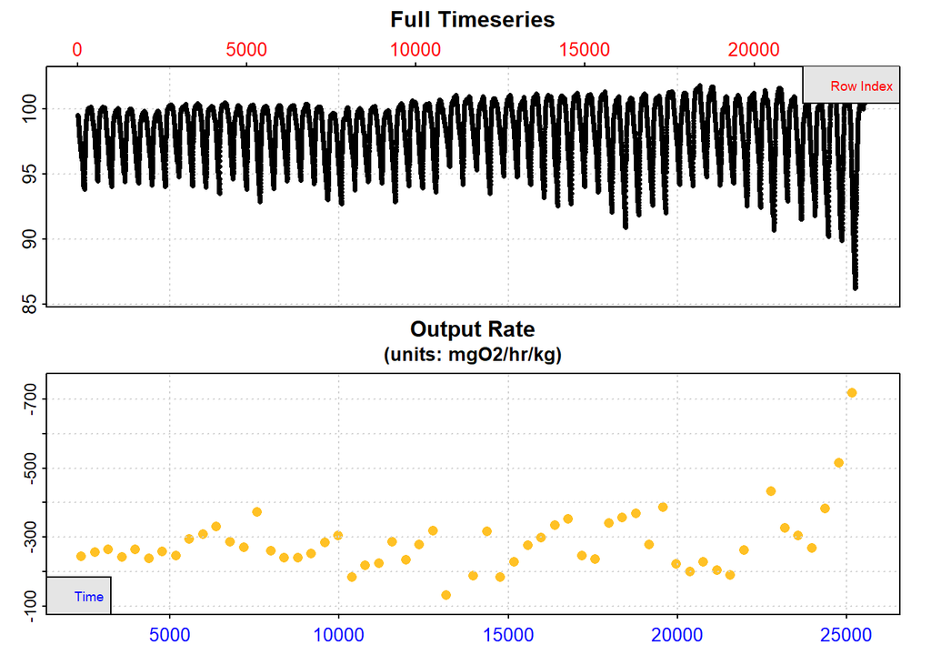

```r
plot(RMR1, type = "rate"); plot(RMR2, type = "rate"); plot(RMR3, type = "rate")
```